# Assignment 2 - Logistic Regression

ITAO 40420 - Machine Learning

6 Nov 2024

# Assignment 2

For this analysis we will be using churn data. The dataset is stored as `churn_data.rda` which can be loaded in by running the below command if the file is located in your working directory or else by accessing the file through file->open file

```r
load("churn_data.rda") # Load churn dataset
library(ggplot2)
library(plotmo)
library(glmnet)
```

We can view a summary of this dataset by running `summary()`:

```r
summary(churn_data)
```

```
##     gender          SeniorCitizen      Partner           Dependents
##  Length:7032        Min.   :0.0000   Length:7032        Length:7032
##  Class :character   1st Qu.:0.0000   Class :character   Class :character
##  Mode  :character   Median :0.0000   Mode  :character   Mode  :character
##                     Mean   :0.1624
##                     3rd Qu.:0.0000
##                     Max.   :1.0000
##      tenure      PhoneService       MultipleLines      InternetService
##  Min.   : 1.00   Length:7032        Length:7032        Length:7032
##  1st Qu.: 9.00   Class :character   Class :character   Class :character
##  Median :29.00   Mode  :character   Mode  :character   Mode  :character
##  Mean   :32.42
##  3rd Qu.:55.00
##  Max.   :72.00
##  OnlineSecurity     OnlineBackup       DeviceProtection   TechSupport
##  Length:7032        Length:7032        Length:7032        Length:7032
##  Class :character   Class :character   Class :character   Class :character
##  Mode  :character   Mode  :character   Mode  :character   Mode  :character
##
##
##
##  StreamingTV        StreamingMovies      Contract         PaperlessBilling
##  Length:7032        Length:7032        Length:7032        Length:7032
##  Class :character   Class :character   Class :character   Class :character
##  Mode  :character   Mode  :character   Mode  :character   Mode  :character
##
##
##
##  PaymentMethod      MonthlyCharges    TotalCharges        Churn
##  Length:7032        Min.   : 18.25   Min.   :  18.8   Min.   :0.0000
##  Class :character   1st Qu.: 35.59   1st Qu.: 401.4   1st Qu.:0.0000
##  Mode  :character   Median : 70.35   Median :1397.5   Median :0.0000
##                     Mean   : 64.80   Mean   :2283.3   Mean   :0.2658
##                     3rd Qu.: 89.86   3rd Qu.:3794.7   3rd Qu.:1.0000
##                     Max.   :118.75   Max.   :8684.8   Max.   :1.0000
```

The variables we have are:

- Gender - Whether the customer is a male or a female
- SeniorCitizen - Whether the customer is a senior citizen or not (1,0)
- Partner - Whether the customer has a partner or nor (Yes, No)
- Dependents - Whether the customer has dependents or not (Yes, No)
- tenure - Number of months the customer has stayed with the company
- PhoneService - Whether the customer has a phone service of no (Yes, No)
- MultipleLines - Whether the customer has multiple lines or not (Yes, No, No phone service)
- InternetService - Customer’s internet service provider (DSL, Fiber optic, No)
- OnlineSecurity - Whether the customer has online security or not (Yes, No, No internet service)
- OnlineBackup - Whether the customer has online backup or not (Yes, No, No internet service)
- DeviceProtection - Whether the customer has tech support or not (Yes, No, No internet service)
- StreamingTV - Whether the customer has streaming TV or not (Yes, No, No internet service)
- StreamingMovies - Whether the customer has streaming movies or not (Yes, No, No internet service)
- Contract - The contract term of the customer (Month-to-month, One year, Two year)
- PaperlessBilling - Whether the customer has paperless billing or not (Yes, No)
- PaymentMethod - The customer’s payment method (Electronic CHECK, Mailed check, Bank transfer (automatic), Credit card (automatic))
- MonthlyCharges - The amount charged to the customer monthly
- TotalCharges - The total amount charged to the customer
- Churn - Whether the customer churned or not (1 = Yes or 0 = No)

The response variable for this dataset is `Churn`:

```r
summary(as.factor(churn_data$Churn))
```

```
##    0    1
## 5163 1869
```

For the assignment please carry out the following tasks/answer the following questions: (12 Points)

- 1 - Create at least two visualizations potentially revealing factors with predictive power (2 Points)

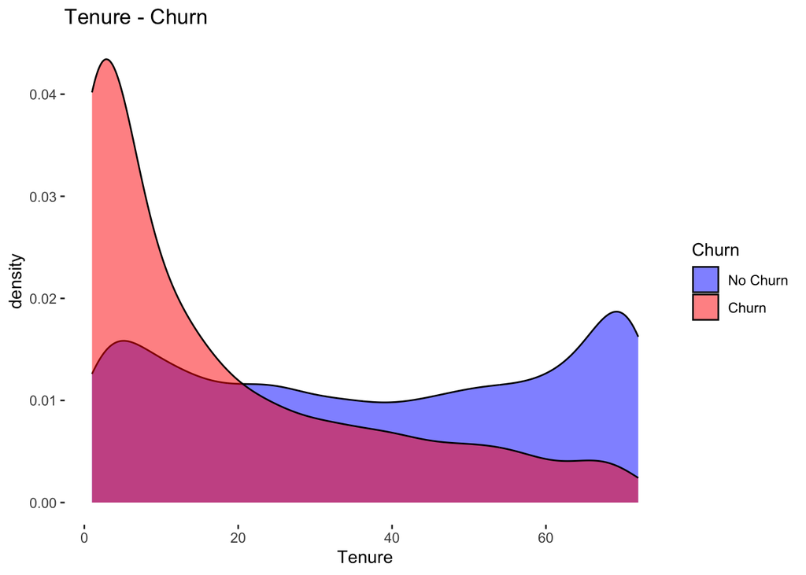

```r
plot_dat <- churn_data
plot_dat$Churn <- as.factor(plot_dat$Churn)
g_1 <- ggplot(plot_dat,
              aes(x = tenure,
                  fill = Churn)) +
  geom_density(alpha = 0.5) +
    theme_set(theme_bw(base_size = 22) ) +
  theme(panel.grid.major = element_blank(),
        panel.grid.minor = element_blank(),
        panel.border = element_blank(),
        panel.background = element_blank()) +
  labs(x = "Tenure", title = "Tenure - Churn",
       fill = "Churn") + # Set labels
  scale_fill_manual(values = c("1" = "red", "0" = "blue"),
                    labels = c("1" = "Churn", "0" = "No Churn"))
g_1
```

This visualization shows that the lower tenure value has a higher churn rate. Meaning the less time a customer has stayed with the company, the more likely they are to churn.

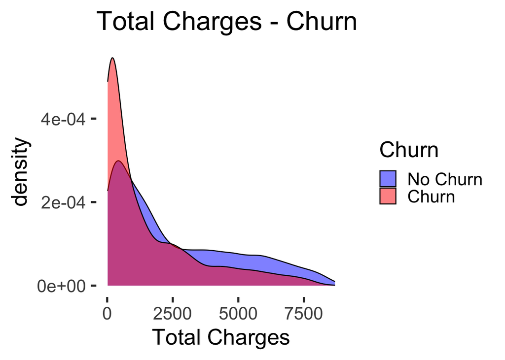

```r
g_2 <- ggplot(plot_dat,
              aes(x = TotalCharges,
                  fill = Churn)) +
  geom_density(alpha = 0.5) +
    theme_set(theme_bw(base_size = 22) ) +
  theme(panel.grid.major = element_blank(),
        panel.grid.minor = element_blank(),
        panel.border = element_blank(),
        panel.background = element_blank()) +
  labs(x = "Total Charges", title = "Total Charges - Churn",
       fill = "Churn") + # Set labels
  scale_fill_manual(values = c("1" = "red", "0" = "blue"),
                    labels = c("1" = "Churn", "0" = "No Churn"))
g_2
```

This visualization shows the more money a customer has spent or was charged, the less like they are to Churn.  
* 2 - Fit a logistic regression model to the data. (Remember you can use `resp ~.,` to include all explanatory variables in the model) (2 Points)

```r
fit1 <- glm(Churn ~ .,
            family = binomial(link = 'logit'),
            data = churn_data)
summary(fit1)
```

```
##
## Call:
## glm(formula = Churn ~ ., family = binomial(link = "logit"), data = churn_data)
##
## Coefficients: (7 not defined because of singularities)
##                                        Estimate Std. Error z value Pr(>|z|)
## (Intercept)                           1.165e+00  8.151e-01   1.430  0.15284
## genderMale                           -2.183e-02  6.480e-02  -0.337  0.73619
## SeniorCitizen                         2.168e-01  8.453e-02   2.564  0.01033 *
## PartnerYes                           -3.840e-04  7.783e-02  -0.005  0.99606
## DependentsYes                        -1.485e-01  8.973e-02  -1.655  0.09796 .
## tenure                               -6.059e-02  6.236e-03  -9.716  < 2e-16 ***
## PhoneServiceYes                       1.715e-01  6.487e-01   0.264  0.79153
## MultipleLinesNo phone service                NA         NA      NA       NA
## MultipleLinesYes                      4.484e-01  1.773e-01   2.530  0.01142 *
## InternetServiceFiber optic            1.747e+00  7.981e-01   2.190  0.02855 *
## InternetServiceNo                    -1.786e+00  8.073e-01  -2.213  0.02691 *
## OnlineSecurityNo internet service            NA         NA      NA       NA
## OnlineSecurityYes                    -2.054e-01  1.787e-01  -1.150  0.25031
## OnlineBackupNo internet service              NA         NA      NA       NA
## OnlineBackupYes                       2.604e-02  1.754e-01   0.148  0.88197
## DeviceProtectionNo internet service          NA         NA      NA       NA
## DeviceProtectionYes                   1.474e-01  1.764e-01   0.836  0.40339
## TechSupportNo internet service               NA         NA      NA       NA
## TechSupportYes                       -1.805e-01  1.806e-01  -0.999  0.31759
## StreamingTVNo internet service               NA         NA      NA       NA
## StreamingTVYes                        5.905e-01  3.263e-01   1.810  0.07035 .
## StreamingMoviesNo internet service           NA         NA      NA       NA
## StreamingMoviesYes                    5.993e-01  3.267e-01   1.834  0.06658 .
## ContractOne year                     -6.608e-01  1.076e-01  -6.142 8.15e-10 ***
## ContractTwo year                     -1.357e+00  1.764e-01  -7.691 1.46e-14 ***
## PaperlessBillingYes                   3.424e-01  7.450e-02   4.596 4.31e-06 ***
## PaymentMethodCredit card (automatic) -8.779e-02  1.141e-01  -0.770  0.44156
## PaymentMethodElectronic check         3.045e-01  9.450e-02   3.222  0.00127 **
## PaymentMethodMailed check            -5.759e-02  1.149e-01  -0.501  0.61627
## MonthlyCharges                       -4.034e-02  3.176e-02  -1.270  0.20392
## TotalCharges                          3.289e-04  7.063e-05   4.657 3.20e-06 ***
## ---
## Signif. codes:  0 '***' 0.001 '**' 0.01 '*' 0.05 '.' 0.1 ' ' 1
##
## (Dispersion parameter for binomial family taken to be 1)
##
##     Null deviance: 8143.4  on 7031  degrees of freedom
## Residual deviance: 5826.3  on 7008  degrees of freedom
## AIC: 5874.3
##
## Number of Fisher Scoring iterations: 6
```

- 3 - What features are significant in your logistic regression model? (1 Point)

```r
summary_fit1 <- summary(fit1)
fit1_coef <- summary_fit1$coefficients[summary_fit1$coefficients[,4] < 0.001, ]
fit1_coef
```

```
##                          Estimate   Std. Error   z value     Pr(>|z|)
## tenure              -0.0605875758 6.235677e-03 -9.716279 2.570009e-22
## ContractOne year    -0.6607952874 1.075853e-01 -6.142058 8.145911e-10
## ContractTwo year    -1.3571062357 1.764452e-01 -7.691377 1.455602e-14
## PaperlessBillingYes  0.3423536429 7.449538e-02  4.595636 4.314313e-06
## TotalCharges         0.0003289402 7.062777e-05  4.657378 3.202625e-06
```

The features that are significant in the logistic regression model are `tenure`, `ContractOne year`, `ContractTwo year`, `PaperlessBillingYes`, and `TotalCharges`.

- 4 - What is the AIC of your logistic regression model? (1 Point)  
  The AIC of `fit1` is 5874.3.
- 5 - Add an interaction term to the logistic regression model? (1 Point)

```r
fit2 <- glm(Churn ~ . + PaymentMethod*Contract,
            family = binomial(link = 'logit'),
            data = churn_data)
summary(fit2)
```

```
##
## Call:
## glm(formula = Churn ~ . + PaymentMethod * Contract, family = binomial(link = "logit"),
##     data = churn_data)
##
## Coefficients: (7 not defined because of singularities)
##                                                         Estimate Std. Error
## (Intercept)                                            1.138e+00  8.158e-01
## genderMale                                            -2.466e-02  6.484e-02
## SeniorCitizen                                          2.222e-01  8.453e-02
## PartnerYes                                             4.656e-03  7.790e-02
## DependentsYes                                         -1.475e-01  8.971e-02
## tenure                                                -5.866e-02  6.270e-03
## PhoneServiceYes                                        1.792e-01  6.484e-01
## MultipleLinesNo phone service                                 NA         NA
## MultipleLinesYes                                       4.556e-01  1.773e-01
## InternetServiceFiber optic                             1.770e+00  7.978e-01
## InternetServiceNo                                     -1.780e+00  8.069e-01
## OnlineSecurityNo internet service                             NA         NA
## OnlineSecurityYes                                     -1.988e-01  1.787e-01
## OnlineBackupNo internet service                               NA         NA
## OnlineBackupYes                                        3.282e-02  1.753e-01
## DeviceProtectionNo internet service                           NA         NA
## DeviceProtectionYes                                    1.472e-01  1.765e-01
## TechSupportNo internet service                                NA         NA
## TechSupportYes                                        -1.765e-01  1.805e-01
## StreamingTVNo internet service                                NA         NA
## StreamingTVYes                                         5.966e-01  3.262e-01
## StreamingMoviesNo internet service                            NA         NA
## StreamingMoviesYes                                     6.086e-01  3.266e-01
## ContractOne year                                      -7.017e-01  2.072e-01
## ContractTwo year                                      -1.100e+00  2.704e-01
## PaperlessBillingYes                                    3.399e-01  7.450e-02
## PaymentMethodCredit card (automatic)                  -1.091e-01  1.364e-01
## PaymentMethodElectronic check                          3.086e-01  1.084e-01
## PaymentMethodMailed check                              4.793e-03  1.288e-01
## MonthlyCharges                                        -4.051e-02  3.174e-02
## TotalCharges                                           2.999e-04  7.152e-05
## ContractOne year:PaymentMethodCredit card (automatic)  2.160e-01  2.829e-01
## ContractTwo year:PaymentMethodCredit card (automatic) -2.526e-01  3.953e-01
```

[output cut: 37 more lines]

```
## ContractTwo year:PaymentMethodCredit card (automatic)  -0.639 0.522858
## ContractOne year:PaymentMethodElectronic check          0.365 0.715228
## ContractTwo year:PaymentMethodElectronic check         -0.146 0.883590
## ContractOne year:PaymentMethodMailed check             -0.559 0.576447
## ContractTwo year:PaymentMethodMailed check             -1.976 0.048122 *
## ---
## Signif. codes:  0 '***' 0.001 '**' 0.01 '*' 0.05 '.' 0.1 ' ' 1
##
## (Dispersion parameter for binomial family taken to be 1)
##
##     Null deviance: 8143.4  on 7031  degrees of freedom
## Residual deviance: 5819.3  on 7002  degrees of freedom
## AIC: 5879.3
##
## Number of Fisher Scoring iterations: 7
```

- 6 - Does the addition of the interaction term increase or decrease the AIC? What is the new AIC for the model? (1 Point)  
  The addition of the interaction term increases the AIC by 5. The new AIC for the model is 5879.3.
- 7 - Fit a lasso logistic regression model to the data. (1 Point)

```r
# Standardize Continuous Variables
x_data <- as.data.frame(churn_data)
x_data$tenure <- scale(x_data$tenure)
x_data$MonthlyCharges <- scale(x_data$MonthlyCharges)
x_data$TotalCharges <- scale(x_data$TotalCharges)

# X Variables
x_vars <- model.matrix(Churn ~.,
                       x_data)[,-1]
# Find the Best Lambda
set.seed(123)
lambda_seq <- 10^seq(4, -4, by = -.1)

# Fit cross-validated lasso model
cv.lasso <- cv.glmnet(x = x_vars,
                 y = churn_data$Churn,
                 alpha = 1,
                 family = "binomial", # Logistic Regression
                 lambda = lambda_seq,
                 nfolds = 10)

best_lam <- cv.lasso$lambda.1se
best_lam # Extract best lambda
```

```
## [1] 0.007943282
```

```r
lasso_fit <- glmnet(x = x_vars,
                    y = churn_data$Churn,
                    alpha = 1,
                    family = "binomial",
                    lambda = best_lam)
coef(lasso_fit)
```

```
## 31 x 1 sparse Matrix of class "dgCMatrix"
##                                                 s0
## (Intercept)                          -1.510665e+00
## genderMale                            .
## SeniorCitizen                         1.778105e-01
## PartnerYes                            .
## DependentsYes                        -9.459825e-02
## tenure                               -7.679557e-01
## PhoneServiceYes                      -1.976371e-01
## MultipleLinesNo phone service         .
## MultipleLinesYes                      1.302274e-01
## InternetServiceFiber optic            8.581293e-01
## InternetServiceNo                    -5.084882e-01
## OnlineSecurityNo internet service    -5.509561e-03
## OnlineSecurityYes                    -2.735554e-01
## OnlineBackupNo internet service      -9.616764e-02
## OnlineBackupYes                       .
## DeviceProtectionNo internet service  -2.458829e-03
## DeviceProtectionYes                   .
## TechSupportNo internet service       -5.341052e-16
## TechSupportYes                       -2.339731e-01
## StreamingTVNo internet service       -8.657609e-02
## StreamingTVYes                        1.592712e-01
## StreamingMoviesNo internet service   -1.494834e-03
## StreamingMoviesYes                    1.753807e-01
## ContractOne year                     -5.251010e-01
## ContractTwo year                     -9.940615e-01
## PaperlessBillingYes                   2.818960e-01
## PaymentMethodCredit card (automatic)  .
## PaymentMethodElectronic check         3.641636e-01
## PaymentMethodMailed check             .
## MonthlyCharges                        .
## TotalCharges                          .
```

```r
# Index coefficients that are non-zero positive/negative
coef_lasso <- cbind.data.frame(as.vector(coef(lasso_fit)))
rownames(coef_lasso) <- rownames(as.matrix(coef(lasso_fit)))
colnames(coef_lasso)[1] <- 'BestLambdaLogisticRegression'
positive_coef <- coef_lasso[coef_lasso$BestLambdaLogisticRegression > 0, , drop=F]
negative_coef <- coef_lasso[coef_lasso$BestLambdaLogisticRegression < 0, , drop=F]
```

- 8 - Which coefficients were non-zero in the lasso model? Were they positive or negative? What does this imply? (1 Point)  
  The coefficients that were positive and non-zero are `SeniorCitizen`, `MultipleLinesYes`,`InternetServiceFiber optic`, `StreamingTVYes`, `StreamingMoviesYes`, `PaperlessBillingYes` and `PaymentMethodElectronic check`.  
  The coefficients that were non-zero and negative in the lasso model are `DependentsYes`, `tenure`, `PhoneServiceYes`, `InternetServiceNo`, `OnlineSecurityNo internet service`, `OnlineSecurityYes`, `OnlineBackupNo internet service`, `DeviceProtectionNo internet service`, `TechSupportNo internet service`, `TechSupportYes`, `StreamingTVNo internet service`, `StreamingMoviesNo internet service`, `ContractOne year`, and `ContractTwo year`.

The positive coefficients imply the increased likelihood of a customer churn, while the negative coefficients imply the decreased likelihood of a customer churn.

2 Points for analysis decisions and code quality.

Please submit an an R-markdown document with the answers, optionally you can submit an R-script with the code used for your analysis and a document answering the specific questions, you can use word, pdf etc.

Assignments can be submitted via Canvas or by email to mbarron2@nd.edu.